# arima

Adrian Scholl, Ludvig Bergstrand

2025-05-11

# Final Project: ARIMAX model for Electricity Consumption in Spain

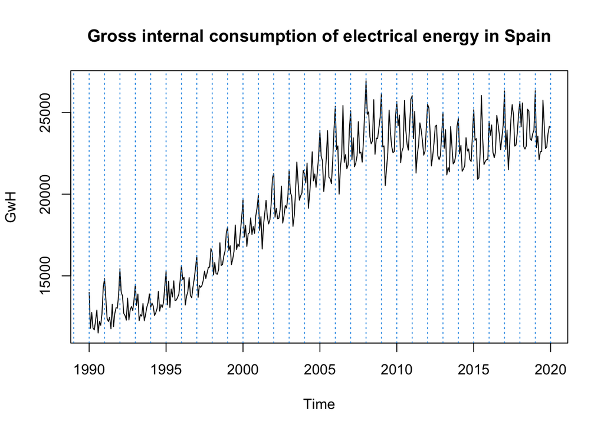

```r
serie=window(ts(read.table("ConsumElec.dat"),start=1990,freq=12))
plot(serie, main="Gross internal consumption of electrical energy in Spain", ylab="GwH")
abline(v=1985:2020,lty=3,col=4)
```

```r
serie
```

```
##        Jan   Feb   Mar   Apr   May   Jun   Jul   Aug   Sep   Oct   Nov   Dec
## 1990 13986 11785 12767 11805 11693 12254 12900 11502 12207 11973 12682 14291
## 1991 14829 13614 12393 12203 12461 11761 13256 11882 12692 13052 13018 13865
## 1992 15434 13991 13779 12694 12568 12292 13641 12301 12914 13124 12877 13532
## 1993 14482 13184 13885 12259 12624 12532 13308 12247 12628 13089 13342 13895
## 1994 13079 13332 13150 12572 12747 13012 14043 12842 13236 13071 13364 14348
## 1995 15268 13224 14671 13069 14192 13706 14697 13490 13519 13683 13886 14746
## 1996 15626 14767 14909 13216 13753 14041 14897 13797 13657 14329 14834 15509
## 1997 16248 13690 14412 14293 14415 14725 15287 14842 15179 15519 15537 16666
## 1998 16418 15052 15818 15128 15101 15393 17021 15639 15689 16192 16517 17641
## 1999 17996 16551 16842 15686 16026 16503 18110 16610 16960 16797 17716 18567
## 2000 19656 17378 18085 16801 17555 17647 18550 17543 18019 17600 18678 19162
## 2001 19927 17785 18626 16643 18098 18840 19618 18615 18179 18439 19411 20996
## 2002 21258 18594 19127 18493 18533 19080 20494 18230 18687 19312 19147 19851
## 2003 21447 20085 19890 18031 18690 20174 21967 20710 19633 19903 20073 21461
```

[output cut: 16 more lines]

## A.1 Identification

### Plot Annual Mean(12m) vs. Variance(12m) Boxplot -> Stationarity: constant var for each level

-> higher variance for at higher consumption level -> non-constant var: non-stationary

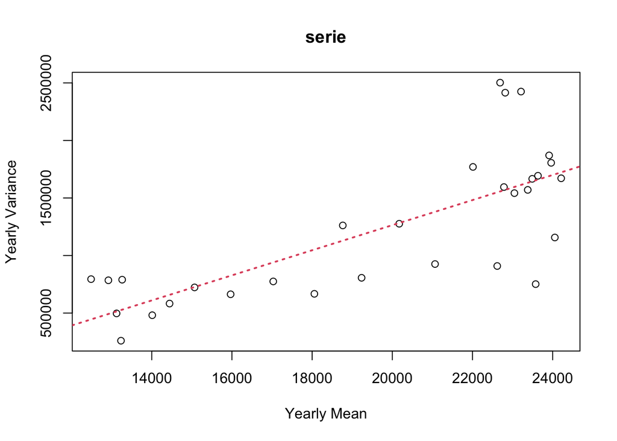

```r
m=apply(matrix(serie,nr=12),2,mean)
v=apply(matrix(serie,nr=12),2,var)
plot(m,v,xlab="Yearly Mean",ylab="Yearly Variance",main="serie")
abline(lm(v~m),col=2,lty=3,lwd=2)
```

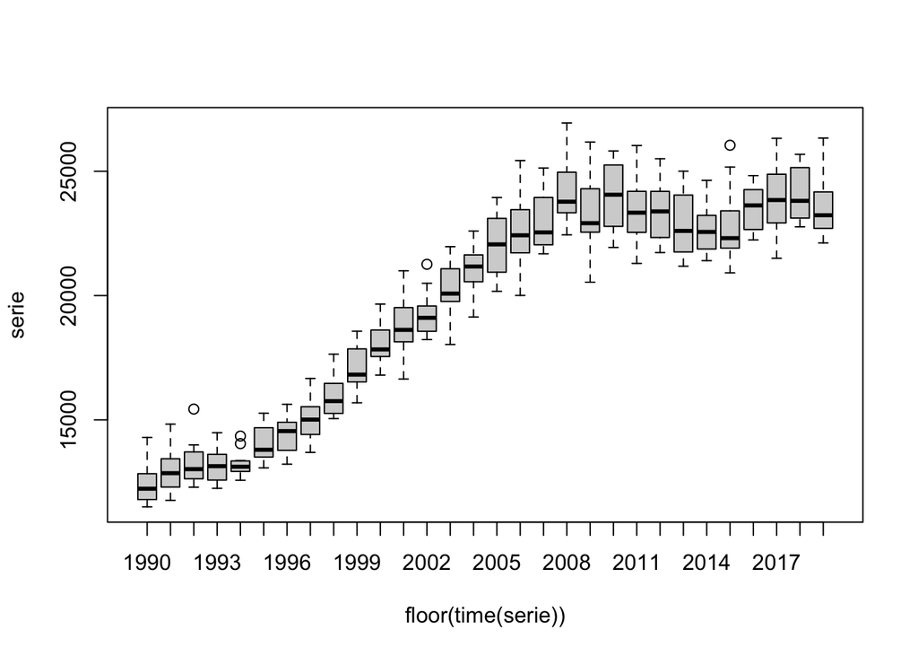

```r
boxplot(serie~floor(time(serie)))
```

Clearly, an increasing variance confirmed. Thus a log transformation applied to stabilize the variance!

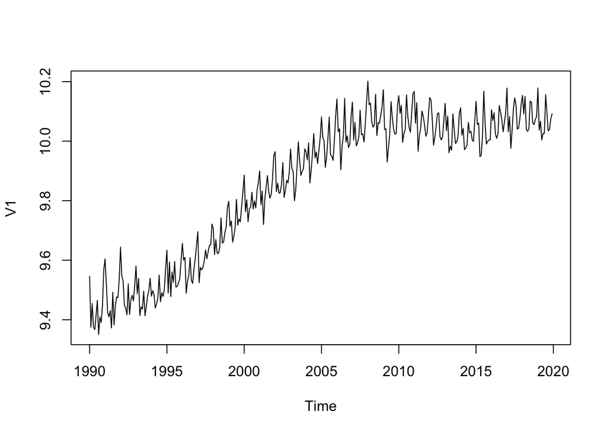

```r
lnserie=log(serie)
plot(lnserie)
```

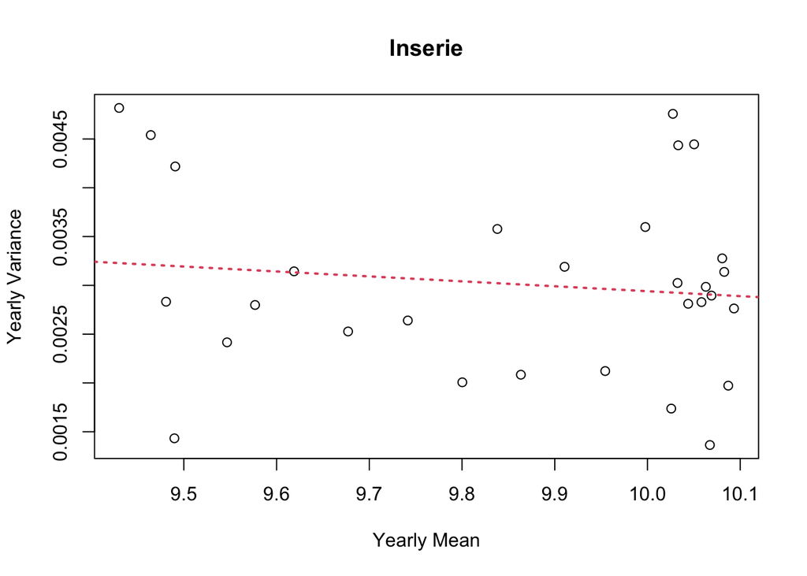

```r
m=apply(matrix(lnserie,nr=12),2,mean)
v=apply(matrix(lnserie,nr=12),2,var)
plot(m,v,xlab="Yearly Mean",ylab="Yearly Variance",main="lnserie")
abline(lm(v~m),col=2,lty=3,lwd=2)
```

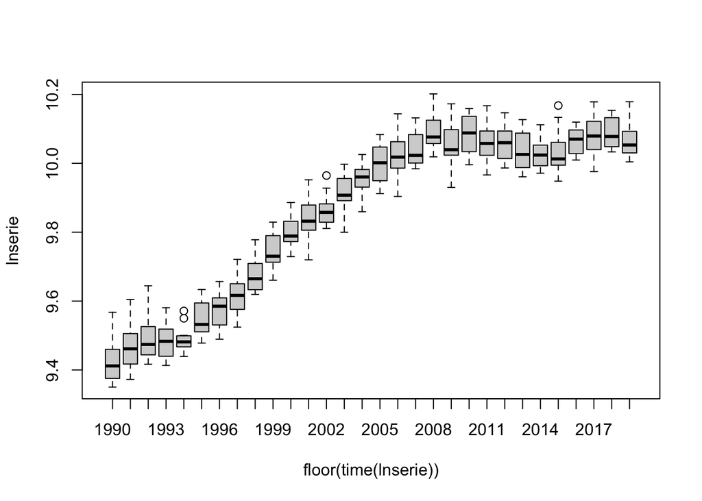

```r
boxplot(lnserie~floor(time(lnserie)))
```

Then, variance seemingly constant!

### Month BoxPlot -> Yearly Seasonality

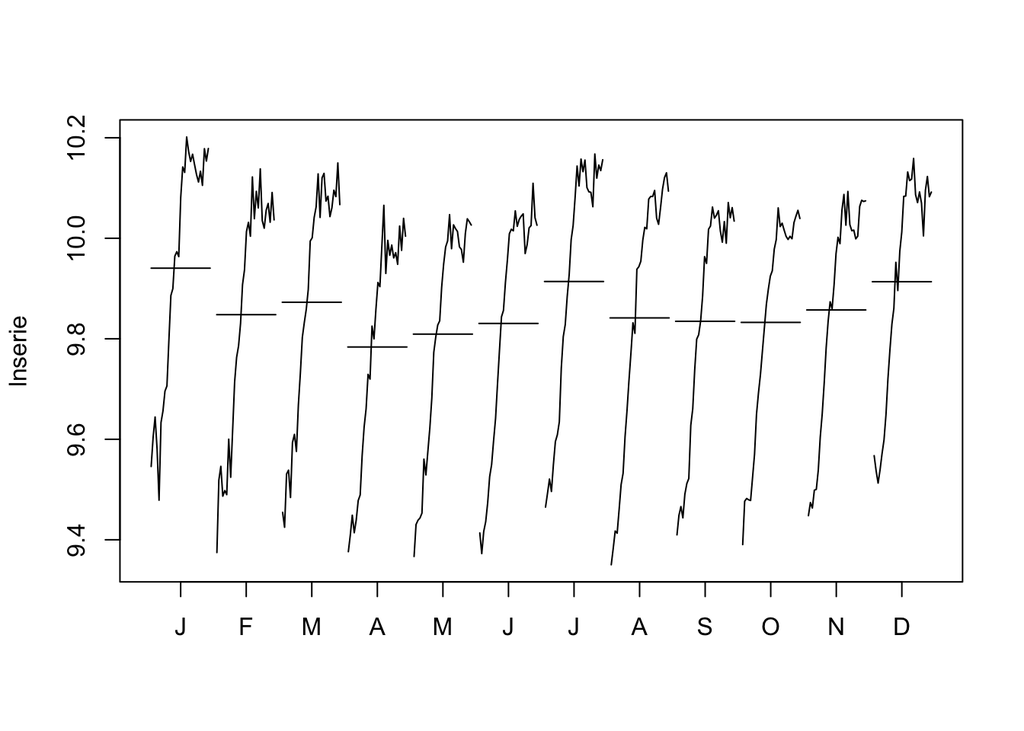

```r
monthplot(lnserie)
```

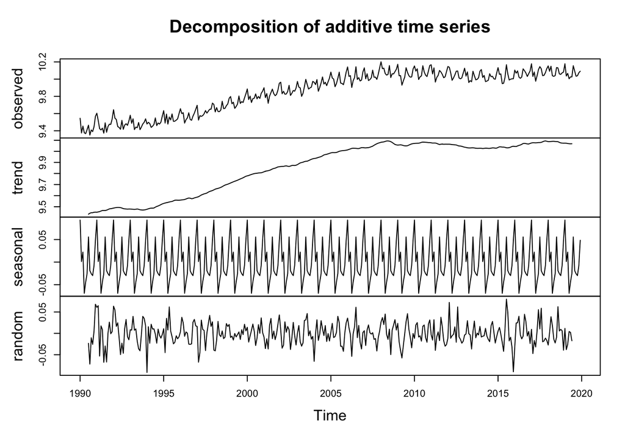

```r
plot(decompose(lnserie))
```

Clearly seasonality is present with s=12 months. Higher consumption in winter (for heating?). Higher again in July (AC cooling).

Eliminate the seasonality applying a seasonal difference.

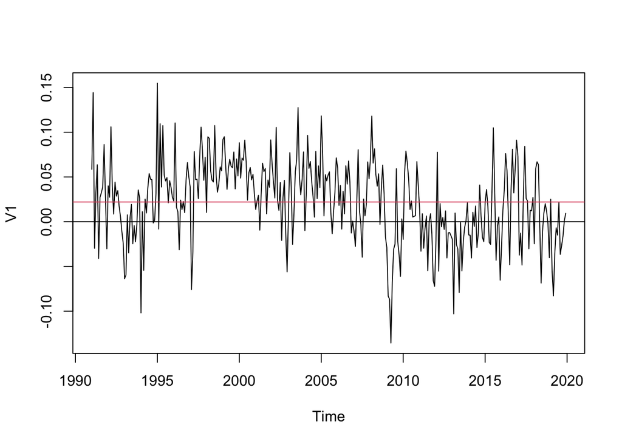

```r
d12lnserie=diff(lnserie,12)
plot(d12lnserie)
abline(h=0)
abline(h=mean(d12lnserie),col=2)
```

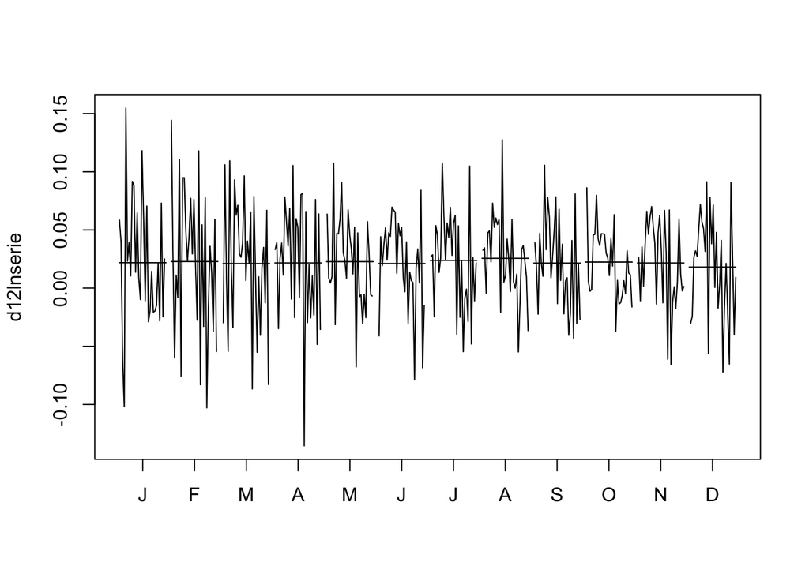

```r
monthplot(d12lnserie)
```

```r
cat("Var for d=0:", var(d12lnserie))
```

```
## Var for d=0: 0.00202945
```

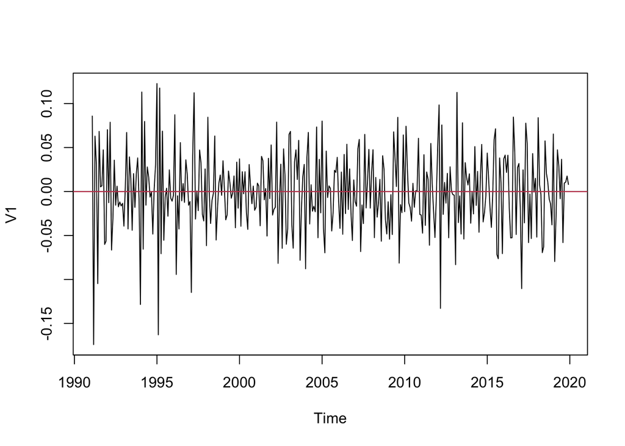

```r
d1d12lnserie=diff(d12lnserie,1)
plot(d1d12lnserie)
abline(h=0)
abline(h=mean(d1d12lnserie),col=2)
```

```r
cat("Var for d=1:", var(d1d12lnserie))
```

```
## Var for d=1: 0.002174466
```

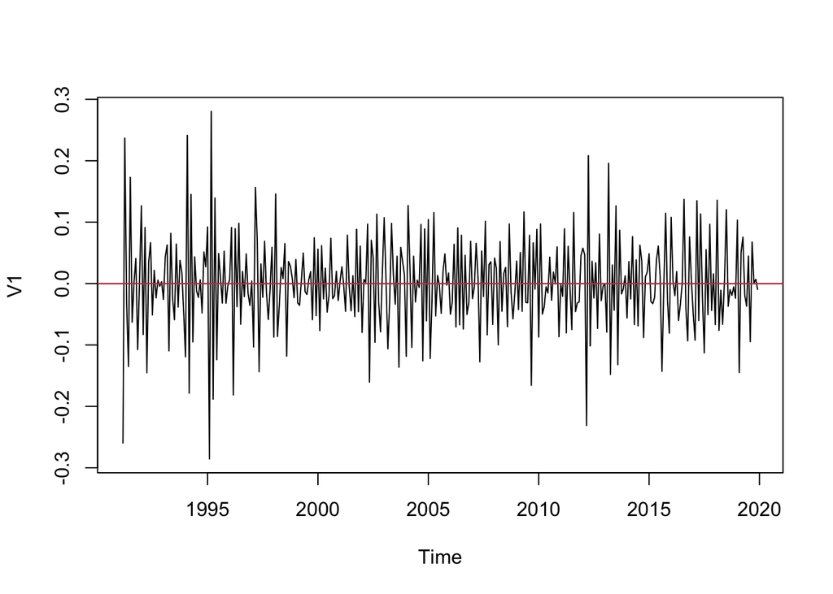

```r
# 2nd regular difference
d1d1d12lnserie=diff(d1d12lnserie,1)
plot(d1d1d12lnserie)
abline(h=0)
abline(h=mean(d1d1d12lnserie),col=2)
```

```r
cat("\nVar for d=2:", var(d1d1d12lnserie))
```

```
##
## Var for d=2: 0.005982176
```

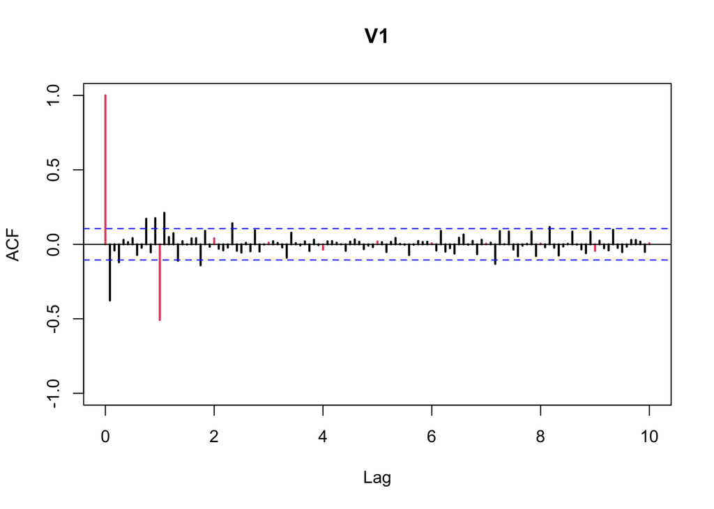

```r
acf(d1d12lnserie, ylim=c(-1,1),col=c(2,rep(1,11)), lwd=2, lag.max=120)
```

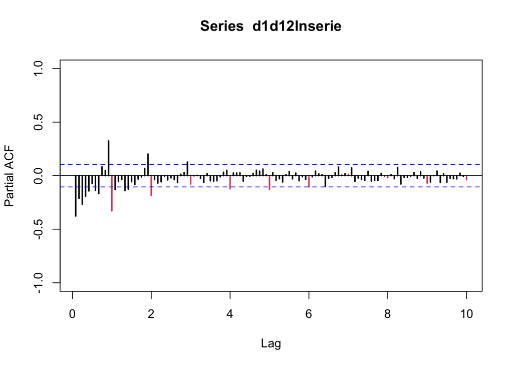

```r
pacf(d1d12lnserie, ylim=c(-1,1),col=c(rep(1,11),2), lwd=2, lag.max=120)
```

#### Seasonal Autoregressive Part P We only take into account the red lags that are multiple of the seasonal period; for s=12, only lags 12, 24, 36, 48 and so on are considered. PACF shows 2 significantly negative lags indicating the possibility of a AR(2) process. However, the ACF doesn’t show a clear decay in the lags, only 1 strongly negative seasonal lag and after that no significant seasonal autocorrelation. –> P=0,1,2 are still tried and let the AIC decide if suitable.

#### Seasonal Moving Average Part Q

ACF shows 1 clear significant negative lag –> Clear MA(1) model behavior with Q=1 and negative coefficient. No signs for Q=2, clearly insignificant. PACF also shows decaying behavior with only 2 strictly significant lags with rather small values. After that still some small, but with 95% confidence significant value -> due to noise or AR/seasonal effects –> Q=1

-> in total ACF and PACF rather point to a SMA model than a SAR model.

#### Regular Autoregressive Part p

- We observe a ACF with not clearly exponentially decaying pattern. Rather 1-3 significant spikes and then insignifcant.
- The first lags 5 are all significantly negative, only then the lags start to become weaker before they increase before the end of the due to the seasonal correlation behavior.
- Like in the SAR case, we still check all model combinations with p=0,1,2 while p=0 seems the most suitable from the ACF and PACF plots. Model with higher p are discarded due to the risk of overfitting and a preference towards parsimonoius models. –>p=0,1,2

#### Regular Moving Avergae Part q

- PCAF shows a decay with the first lag of the ACF clearly being significantly negative. The second ACF lag is very close to 0 while the 3rd lag is slightly significant again.
- This indicates a clear MA(1) behavior. We decide to also check the AIC for MA(2) and MA(3) –> q=1,2,3

### Conclusion:

SARIMA(0,1,1)(0,1,1)[12] MA(1) + seasonal MA(1) — common baseline SARIMA(1,1,1)(0,1,1)[12] Adds AR(1) SARIMA(1,1,1)(1,1,1)[12] Full general model SARIMA(0,1,1)(1,1,1)[12] MA(1) + seasonal AR(1)

We use the CLT to assume that the estimates are asymptotically normal distributed and check if the 95% confidence interval of the estimates overlaps with 0.

To systematically cover reasonable variants without overfitting, we want to test:

Non-seasonal AR (p):

Non-seasonal MA (q):

Seasonal AR (P):

Seasonal MA (Q):

Seasonal period: 12

Differencing: d = 1, D = 1

To avoid overparameterization (too many parameters relative to data), we’ll limit total parameters (p + q + P + Q ≤ 6) and exclude redundant/ill-posed combinations.

```r
library(dplyr)
# Define the models to test under the constraints
model_specs <- list()

for (p in 0:2) {
  for (q in 0:3) {
    for (P in 0:2) {
      for (Q in 0:1) {
        total_order <- p + q + P + Q
        if (total_order <= 6) { # restriction to prevent overparametrization
          model_name <- sprintf("SARIMA(%d,1,%d)(%d,1,%d)[12]", p, q, P, Q)
          model_specs[[model_name]] <- list(order = c(p,1,q), seasonal = c(P,1,Q), ParamCount = total_order)
        }
      }
    }
  }
}

results <- list()

# Fit all models with warning/error handling
for (model_name in names(model_specs)) {
  spec <- model_specs[[model_name]]
  status <- "OK"

  fit <- withCallingHandlers(
    tryCatch({
      arima(
        lnserie,
        order = spec$order,
        seasonal = list(order = spec$seasonal, period = 12),
        method = "ML"
      )
    }, error = function(e) {
      status <<- paste("Error:", e$message)
      return(NULL)
    }),
    warning = function(w) {
      status <<- paste("Warning:", conditionMessage(w))
      invokeRestart("muffleWarning")
    }
  )

  if (!is.null(fit)) {
    se <- sqrt(diag(fit$var.coef))
    coefs <- fit$coef
    lower <- coefs - 1.96 * se
    upper <- coefs + 1.96 * se
    signif <- !(lower <= 0 & upper >= 0)

    results[[model_name]] <- list(
      Coefs = coefs,
      Significant = signif,
      AIC = fit$aic,
      BIC = AIC(fit, k = log(length(lnserie))),
      LogLik = as.numeric(logLik(fit)),
      Sigma2 = fit$sigma2,
      Status = status,
      ParamCount = spec$ParamCount
    )
  } else {
    results[[model_name]] <- list(
      Coefs = NA,
      Significant = NA,
      AIC = NA,
      BIC = NA,
      LogLik = NA,
      Sigma2 = NA,
      Status = status,
      ParamCount = spec$ParamCount
    )
  }
}
# Summarize results
summary_table <- bind_rows(lapply(names(results), function(name) {
  res <- results[[name]]
  data.frame(
    Model = name,
    AIC = res$AIC,
    BIC = res$BIC,
    LogLik = res$LogLik,
    Sigma2 = res$Sigma2,
    Coefs = if (!is.null(res$Coefs) && is.numeric(res$Coefs)) paste(names(res$Coefs), round(res$Coefs, 3), sep = "=", collapse = "; ") else NA,
    Insignificant = if (!is.null(res$Significant) && is.logical(res$Significant)) paste(names(res$Significant)[!res$Significant], collapse = ", ") else NA,
    ParamCount = res$ParamCount,
    Status = res$Status
  )
}), .id = NULL)

# Print the tables sorted by AIC and BIC
summary_table_aic <- summary_table %>% arrange(AIC)
summary_table_bic <- summary_table %>% arrange(BIC)

cat("\nSorted by AIC:\n")
```

```
##
## Sorted by AIC:
```

```r
print(summary_table_aic)
```

```
##                       Model       AIC       BIC   LogLik       Sigma2
## 1  SARIMA(1,1,1)(1,1,1)[12] -1429.450 -1410.020 719.7251 0.0008922744
## 2  SARIMA(1,1,1)(0,1,1)[12] -1429.138 -1413.594 718.5692 0.0008976112
## 3  SARIMA(0,1,2)(1,1,1)[12] -1428.806 -1409.375 719.4030 0.0008940493
## 4  SARIMA(0,1,2)(0,1,1)[12] -1428.448 -1412.904 718.2241 0.0008994822
## 5  SARIMA(0,1,3)(1,1,1)[12] -1428.015 -1404.699 720.0077 0.0008907142
## 6  SARIMA(0,1,3)(0,1,1)[12] -1427.816 -1408.386 718.9082 0.0008957487
## 7  SARIMA(2,1,3)(0,1,1)[12] -1427.802 -1400.599 720.9009 0.0008849304
## 8  SARIMA(2,1,1)(1,1,1)[12] -1427.488 -1404.171 719.7439 0.0008921533
## 9  SARIMA(1,1,1)(2,1,1)[12] -1427.481 -1404.164 719.7404 0.0008923138
## 10 SARIMA(1,1,2)(1,1,1)[12] -1427.471 -1404.155 719.7356 0.0008922064
## 11 SARIMA(2,1,1)(0,1,1)[12] -1427.185 -1407.755 718.5927 0.0008974530
## 12 SARIMA(1,1,2)(0,1,1)[12] -1427.164 -1407.733 718.5820 0.0008975253
## 13 SARIMA(0,1,2)(2,1,1)[12] -1426.835 -1403.518 719.4175 0.0008940964
## 14 SARIMA(1,1,3)(1,1,1)[12] -1426.120 -1398.917 720.0599 0.0008904710
```

[output cut: 257 more lines]

```r
cat("\nSorted by BIC:\n")
```

```
##
## Sorted by BIC:
```

```r
print(summary_table_bic)
```

```
##                       Model       AIC       BIC   LogLik       Sigma2
## 1  SARIMA(1,1,1)(0,1,1)[12] -1429.138 -1413.594 718.5692 0.0008976112
## 2  SARIMA(0,1,2)(0,1,1)[12] -1428.448 -1412.904 718.2241 0.0008994822
## 3  SARIMA(1,1,1)(1,1,1)[12] -1429.450 -1410.020 719.7251 0.0008922744
## 4  SARIMA(0,1,2)(1,1,1)[12] -1428.806 -1409.375 719.4030 0.0008940493
## 5  SARIMA(0,1,3)(0,1,1)[12] -1427.816 -1408.386 718.9082 0.0008957487
## 6  SARIMA(0,1,1)(0,1,1)[12] -1419.995 -1408.337 712.9975 0.0009283363
## 7  SARIMA(2,1,1)(0,1,1)[12] -1427.185 -1407.755 718.5927 0.0008974530
## 8  SARIMA(1,1,2)(0,1,1)[12] -1427.164 -1407.733 718.5820 0.0008975253
## 9  SARIMA(0,1,1)(1,1,1)[12] -1420.698 -1405.153 714.3489 0.0009216723
## 10 SARIMA(0,1,3)(1,1,1)[12] -1428.015 -1404.699 720.0077 0.0008907142
## 11 SARIMA(2,1,1)(1,1,1)[12] -1427.488 -1404.171 719.7439 0.0008921533
## 12 SARIMA(1,1,1)(2,1,1)[12] -1427.481 -1404.164 719.7404 0.0008923138
## 13 SARIMA(1,1,2)(1,1,1)[12] -1427.471 -1404.155 719.7356 0.0008922064
## 14 SARIMA(0,1,2)(2,1,1)[12] -1426.835 -1403.518 719.4175 0.0008940964
```

[output cut: 257 more lines]

### Final Model Choice

```r
(mod1 = arima(
        lnserie,
        order=c(0,1,3),
        seasonal = list(order=c(2,1,1), period = 12)))
```

```
##
## Call:
## arima(x = lnserie, order = c(0, 1, 3), seasonal = list(order = c(2, 1, 1), period = 12))
##
## Coefficients:
##           ma1      ma2      ma3     sar1     sar2     sma1
##       -0.5746  -0.1151  -0.0616  -0.1211  -0.0147  -0.7298
## s.e.   0.0546   0.0633   0.0559   0.0975   0.0827   0.0827
##
## sigma^2 estimated as 0.0008907:  log likelihood = 720.02,  aic = -1426.05
```

SARIMA(0,1,1)(2,1,1)[12]

```r
(mod2 = arima(
        lnserie,
        order=c(0,1,1),
        seasonal = list(order=c(2,1,1), period = 12)))
```

```
##
## Call:
## arima(x = lnserie, order = c(0, 1, 1), seasonal = list(order = c(2, 1, 1), period = 12))
##
## Coefficients:
##           ma1     sar1     sar2     sma1
##       -0.7043  -0.1512  -0.0361  -0.6971
## s.e.   0.0469   0.1024   0.0851   0.0891
##
## sigma^2 estimated as 0.0009214:  log likelihood = 714.44,  aic = -1418.88
```

## A.2 Validation

```r
#################Validation#################################
validation=function(model,dades){
  s=frequency(get(model$series))
  resid=model$residuals
  par(mfrow=c(2,2),mar=c(3,3,3,3))
  #Residuals plot
  plot(resid,main="Residuals")
  abline(h=0)
  abline(h=c(-3*sd(resid),3*sd(resid)),lty=3,col=4)
  #Square Root of absolute values of residuals (Homocedasticity)
  scatter.smooth(sqrt(abs(resid)),main="Square Root of Absolute residuals",
                 lpars=list(col=2))

  #Normal plot of residuals
  qqnorm(resid)
  qqline(resid,col=2,lwd=2)

  ##Histogram of residuals with normal curve
  hist(resid,breaks=20,freq=FALSE)
  curve(dnorm(x,mean=mean(resid),sd=sd(resid)),col=2,add=T)


    # ACF & PACF of residuals
    par(mfrow = c(1, 2))
    acf(resid, ylim = c(-1, 1), lag.max = 60, col = c(2, rep(1, s - 1)), lwd = 1,
        main = "ACF of Residuals")
    pacf(resid, ylim = c(-1, 1), lag.max = 60, col = c(rep(1, s - 1), 2), lwd = 1,
         main = "PACF of Residuals")
    par(mfrow = c(1, 1))

    # ACF & PACF of squared residuals
    par(mfrow = c(1, 2))
    acf(resid^2, ylim = c(-1, 1), lag.max = 60, col = c(2, rep(1, s - 1)), lwd = 1,
        main = "ACF of Squared Residuals")
    pacf(resid^2, ylim = c(-1, 1), lag.max = 60, col = c(rep(1, s - 1), 2), lwd = 1,
         main = "PACF of Squared Residuals")
    par(mfrow = c(1, 1))

  #Ljung-Box p-values
  par(mar=c(2,2,1,1))
  tsdiag(model,gof.lag=7*s)
  cat("\n--------------------------------------------------------------------\n")
  print(model)

  #Stationary and Invertible
  cat("\nModul of AR Characteristic polynomial Roots: ",
      Mod(polyroot(c(1,-model$model$phi))),"\n")
  cat("\nModul of MA Characteristic polynomial Roots: ",
      Mod(polyroot(c(1,model$model$theta))),"\n")

  #Model expressed as an MA infinity (psi-weights)
  psis=ARMAtoMA(ar=model$model$phi,ma=model$model$theta,lag.max=72)
  names(psis)=paste("psi",1:72)
  cat("\nPsi-weights (MA(inf))\n")
  cat("\n--------------------\n")
  print(psis[1:20])

  plot(psis,type="h",main="Psi Weigths - MA(inf)")

  #Model expressed as an AR infinity (pi-weights)
  pis=-ARMAtoMA(ar=-model$model$theta,ma=-model$model$phi,lag.max=72)
  names(pis)=paste("pi",1:72)
  cat("\nPi-weights (AR(inf))\n")
  cat("\n--------------------\n")
  print(pis[1:20])

  plot(pis,type="h",main="Pi Weights - AR(inf)")

  cat("\nNormality Tests\n")
  cat("\n--------------------\n")

  ##Shapiro-Wilks Normality test
  print(shapiro.test(resid(model)))

  suppressMessages(require(nortest,quietly=TRUE,warn.conflicts=FALSE))
  ##Anderson-Darling test
  print(ad.test(resid(model)))

  suppressMessages(require(tseries,quietly=TRUE,warn.conflicts=FALSE))
  ##Jarque-Bera test
  print(jarque.bera.test(resid(model)))

  cat("\nHomoscedasticity Test\n")
  cat("\n--------------------\n")
  suppressMessages(require(lmtest,quietly=TRUE,warn.conflicts=FALSE))
  ##Breusch-Pagan test
  obs=get(model$series)
  print(bptest(resid(model)~I(obs-resid(model))))

  cat("\nIndependence Tests\n")
  cat("\n--------------------\n")

  ##Durbin-Watson test
  print(dwtest(resid(model)~I(1:length(resid(model)))))

  ##Ljung-Box test
  cat("\nLjung-Box test\n")
  print(t(apply(matrix(c(1:4,(1:4)*s)),1,function(el) {
    te=Box.test(resid(model),type="Ljung-Box",lag=el)
    c(lag=(te$parameter),statistic=te$statistic[[1]],p.value=te$p.value)})))

  #Sample ACF vs. Teoric ACF
  par(mfrow=c(2,2),mar=c(3,3,3,3))
  acf(dades, ylim=c(-1,1) ,lag.max=36,main="Sample ACF")

  plot(ARMAacf(model$model$phi,model$model$theta,lag.max=36),ylim=c(-1,1),
       type="h",xlab="Lag",  ylab="", main="Theoretical ACF")
  abline(h=0)

  #Sample PACF vs. Teoric PACF
  pacf(dades, ylim=c(-1,1) ,lag.max=36,main="Sample PACF")

  plot(ARMAacf(model$model$phi,model$model$theta,lag.max=36, pacf=T),ylim=c(-1,1),
       type="h", xlab="Lag", ylab="", main="Theoretical PACF")
  abline(h=0)
  par(mfrow=c(1,1))
}
################# Fi Validación #################################
```

```r
check_stationarity_invertibility <- function(model, label = "Model") {
  cat("\n========== ", label, " ==========\n")

  # Stationarity (Causality) check
  ar_roots <- Mod(polyroot(c(1, -model$model$phi)))
  cat("\nModulus of AR Roots (Stationarity):\n", ar_roots, "\n")
  if (all(ar_roots > 1)) {
    cat("=> AR part is STATIONARY (causal)\n")
  } else {
    cat("=> AR part is NOT stationary!\n")
  }

  # Invertibility check
  ma_roots <- Mod(polyroot(c(1, model$model$theta)))
  cat("\nModulus of MA Roots (Invertibility):\n", ma_roots, "\n")
  if (all(ma_roots > 1)) {
    cat("=> MA part is INVERTIBLE\n")
  } else {
    cat("=> MA part is NOT invertible!\n")
  }

  # Psi-weights (MA(inf))
  psis <- ARMAtoMA(ar = model$model$phi, ma = model$model$theta, lag.max = 72)
  names(psis) <- paste("psi", 1:72)
  cat("\nPsi-weights (MA(inf)):\n")
  print(psis[1:20])
  plot(psis, type = "h", main = paste("Psi Weights -", label))

  # Pi-weights (AR(inf))
  pis <- -ARMAtoMA(ar = -model$model$theta, ma = -model$model$phi, lag.max = 72)
  names(pis) <- paste("pi", 1:72)
  cat("\nPi-weights (AR(inf)):\n")
  print(pis[1:20])
  plot(pis, type = "h", main = paste("Pi Weights -", label))
}
```

### Validation of complexer model: SARIMA(0,1,3)(2,1,1)

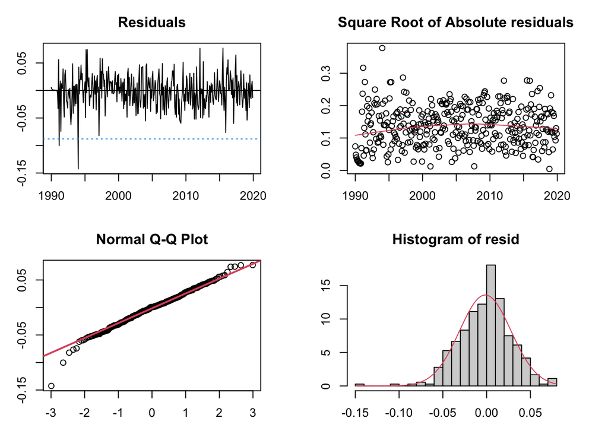

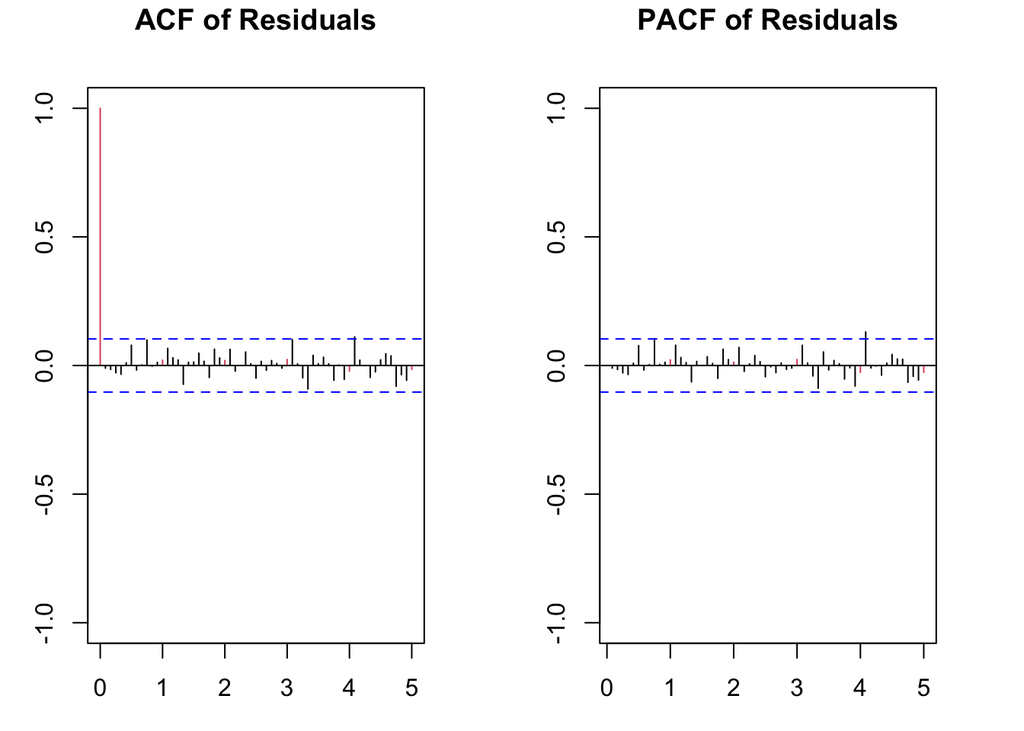

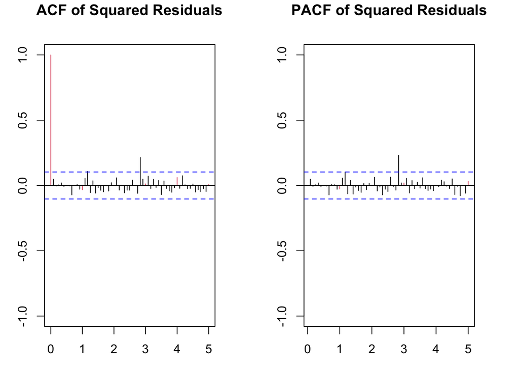

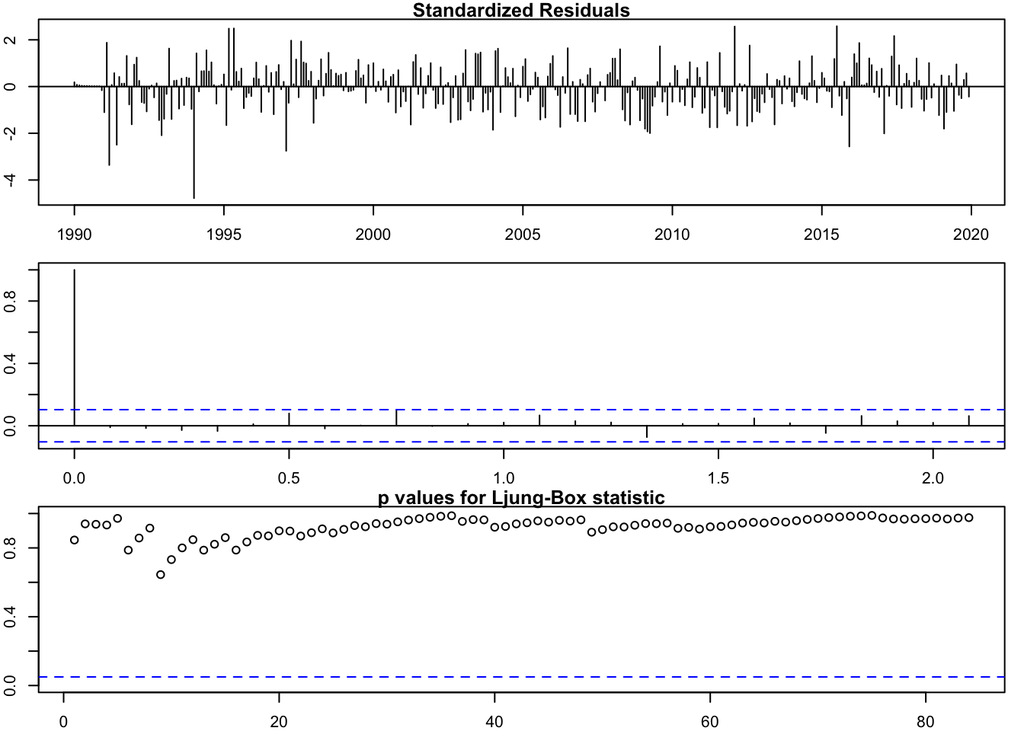

```
##
## --------------------------------------------------------------------
##
## Call:
## arima(x = lnserie, order = c(0, 1, 3), seasonal = list(order = c(2, 1, 1), period = 12))
##
## Coefficients:
##           ma1      ma2      ma3     sar1     sar2     sma1
##       -0.5746  -0.1151  -0.0616  -0.1211  -0.0147  -0.7298
## s.e.   0.0546   0.0633   0.0559   0.0975   0.0827   0.0827
##
## sigma^2 estimated as 0.0008907:  log likelihood = 720.02,  aic = -1426.05
##
## Modul of AR Characteristic polynomial Roots:  1.192301 1.192301 1.192301 1.192301 1.192301 1.192301 1.192301 1.192301 1.192301 1.192301 1.192301 1.192301 1.192301 1.192301 1.192301 1.192301 1.192301 1.192301 1.192301 1.192301 1.192301 1.192301 1.192301 1.192301
##
## Modul of MA Characteristic polynomial Roots:  1.026597 1.026597 1.026597 1.026597 1.026597 1.026597 1.026597 1.026597 1.026597 1.026597 1.026597 1.026597 1.23397 3.627181 3.627181
##
## Psi-weights (MA(inf))
##
## --------------------
##       psi 1       psi 2       psi 3       psi 4       psi 5       psi 6
## -0.57456898 -0.11510097 -0.06159661  0.00000000  0.00000000  0.00000000
##       psi 7       psi 8       psi 9      psi 10      psi 11      psi 12
##  0.00000000  0.00000000  0.00000000  0.00000000  0.00000000 -0.85084253
##      psi 13      psi 14      psi 15      psi 16      psi 17      psi 18
##  0.48886773  0.09793280  0.05240902  0.00000000  0.00000000  0.00000000
##      psi 19      psi 20
##  0.00000000  0.00000000
```

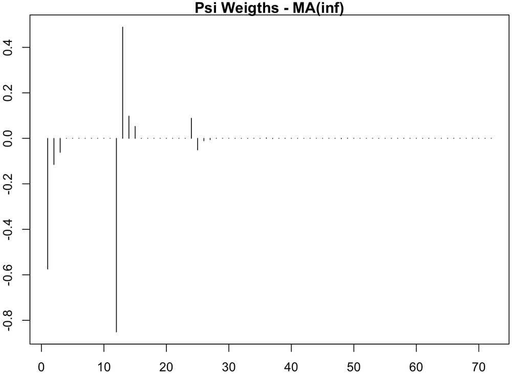

```
##
## Pi-weights (AR(inf))
##
## --------------------
##        pi 1        pi 2        pi 3        pi 4        pi 5        pi 6
## -0.57456898 -0.44523049 -0.38354569 -0.30701142 -0.24797041 -0.20143853
##        pi 7        pi 8        pi 9       pi 10       pi 11       pi 12
## -0.16319283 -0.13222545 -0.10716423 -0.08684464 -0.07037758 -0.90787617
##       pi 13       pi 14       pi 15       pi 16       pi 17       pi 18
## -0.53508735 -0.41627704 -0.35669105 -0.28581707 -0.23091837 -0.18754731
##       pi 19       pi 20
## -0.15194316 -0.12311249
```

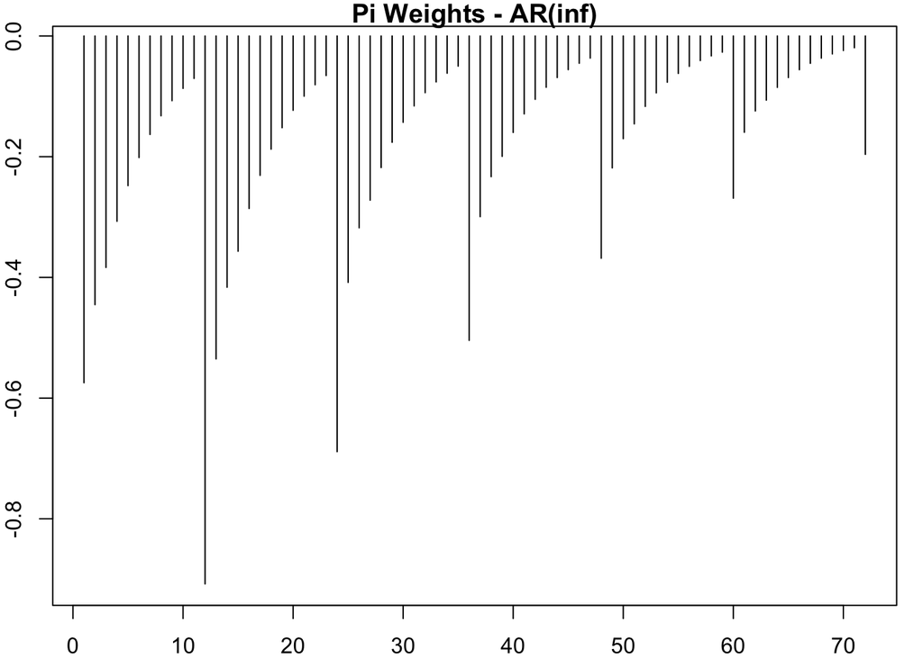

```
##
## Normality Tests
##
## --------------------
##
##  Shapiro-Wilk normality test
##
## data:  resid(model)
## W = 0.98684, p-value = 0.002366
##
##
##  Anderson-Darling normality test
##
## data:  resid(model)
## A = 0.52868, p-value = 0.1761
##
##
##  Jarque Bera Test
##
## data:  resid(model)
## X-squared = 33.354, df = 2, p-value = 5.719e-08
##
##
## Homoscedasticity Test
##
## --------------------
##
##  studentized Breusch-Pagan test
##
## data:  resid(model) ~ I(obs - resid(model))
## BP = 0.64611, df = 1, p-value = 0.4215
##
##
## Independence Tests
##
## --------------------
##
##  Durbin-Watson test
##
## data:  resid(model) ~ I(1:length(resid(model)))
## DW = 2.0215, p-value = 0.5603
## alternative hypothesis: true autocorrelation is greater than 0
##
##
## Ljung-Box test
##      lag.df   statistic   p.value
## [1,]      1  0.03778574 0.8458740
## [2,]      2  0.12425542 0.9397629
## [3,]      3  0.41471765 0.9371857
## [4,]      4  0.83884887 0.9331653
## [5,]     12  7.14547070 0.8478523
## [6,]     24 15.32226597 0.9109738
## [7,]     36 19.76189476 0.9871798
## [8,]     48 32.01567690 0.9631451
```

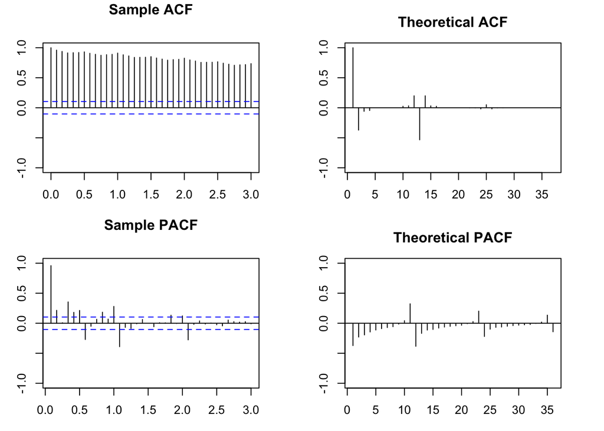

```r
validation(mod1,lnserie)
```

#### Stationarity and Inveritbility

```r
check_stationarity_invertibility(mod1, "SARIMA(0,1,3)(2,1,1)")
```

```
##
## ==========  SARIMA(0,1,3)(2,1,1)  ==========
##
## Modulus of AR Roots (Stationarity):
##  1.192301 1.192301 1.192301 1.192301 1.192301 1.192301 1.192301 1.192301 1.192301 1.192301 1.192301 1.192301 1.192301 1.192301 1.192301 1.192301 1.192301 1.192301 1.192301 1.192301 1.192301 1.192301 1.192301 1.192301
## => AR part is STATIONARY (causal)
##
## Modulus of MA Roots (Invertibility):
##  1.026597 1.026597 1.026597 1.026597 1.026597 1.026597 1.026597 1.026597 1.026597 1.026597 1.026597 1.026597 1.23397 3.627181 3.627181
## => MA part is INVERTIBLE
##
## Psi-weights (MA(inf)):
##       psi 1       psi 2       psi 3       psi 4       psi 5       psi 6
## -0.57456898 -0.11510097 -0.06159661  0.00000000  0.00000000  0.00000000
##       psi 7       psi 8       psi 9      psi 10      psi 11      psi 12
##  0.00000000  0.00000000  0.00000000  0.00000000  0.00000000 -0.85084253
##      psi 13      psi 14      psi 15      psi 16      psi 17      psi 18
##  0.48886773  0.09793280  0.05240902  0.00000000  0.00000000  0.00000000
##      psi 19      psi 20
##  0.00000000  0.00000000
```

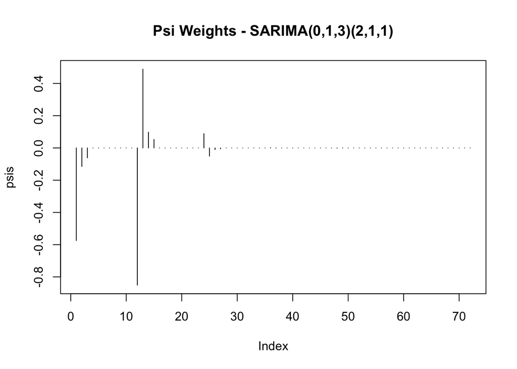

```
##
## Pi-weights (AR(inf)):
##        pi 1        pi 2        pi 3        pi 4        pi 5        pi 6
## -0.57456898 -0.44523049 -0.38354569 -0.30701142 -0.24797041 -0.20143853
##        pi 7        pi 8        pi 9       pi 10       pi 11       pi 12
## -0.16319283 -0.13222545 -0.10716423 -0.08684464 -0.07037758 -0.90787617
##       pi 13       pi 14       pi 15       pi 16       pi 17       pi 18
## -0.53508735 -0.41627704 -0.35669105 -0.28581707 -0.23091837 -0.18754731
##       pi 19       pi 20
## -0.15194316 -0.12311249
```

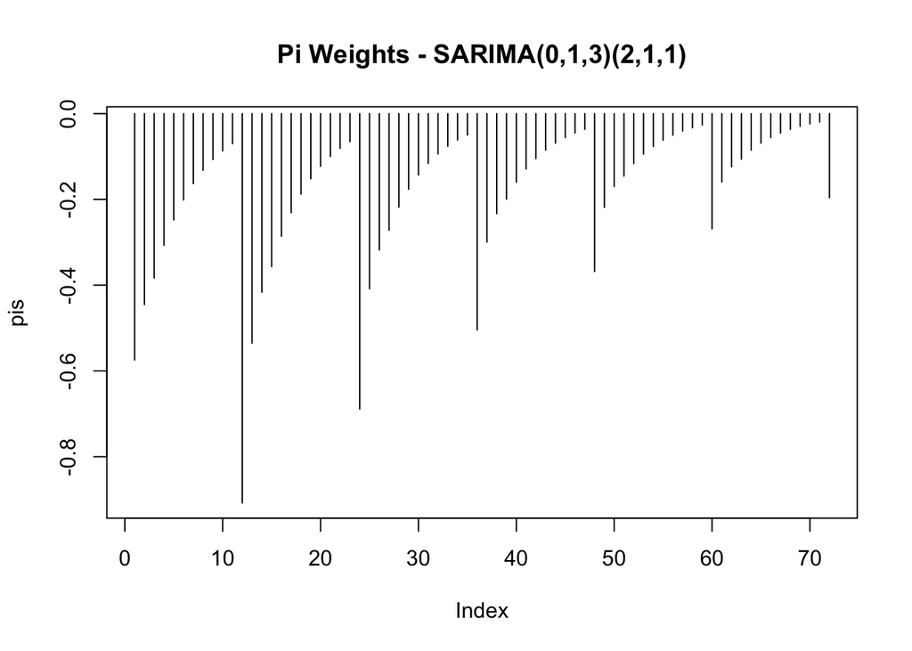

### Validation of simpler model: SARIMA(0,1,1)(2,1,1)

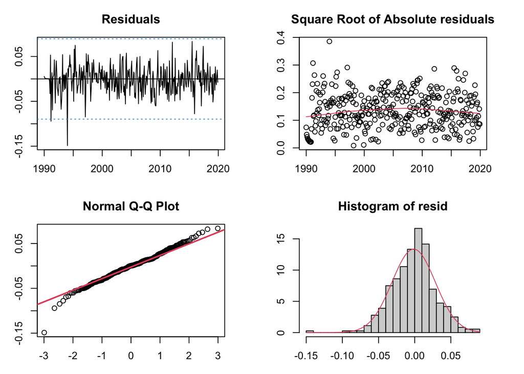

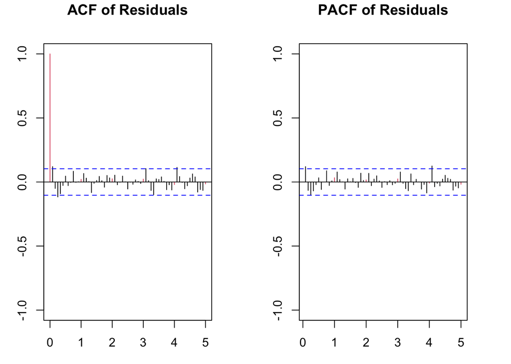

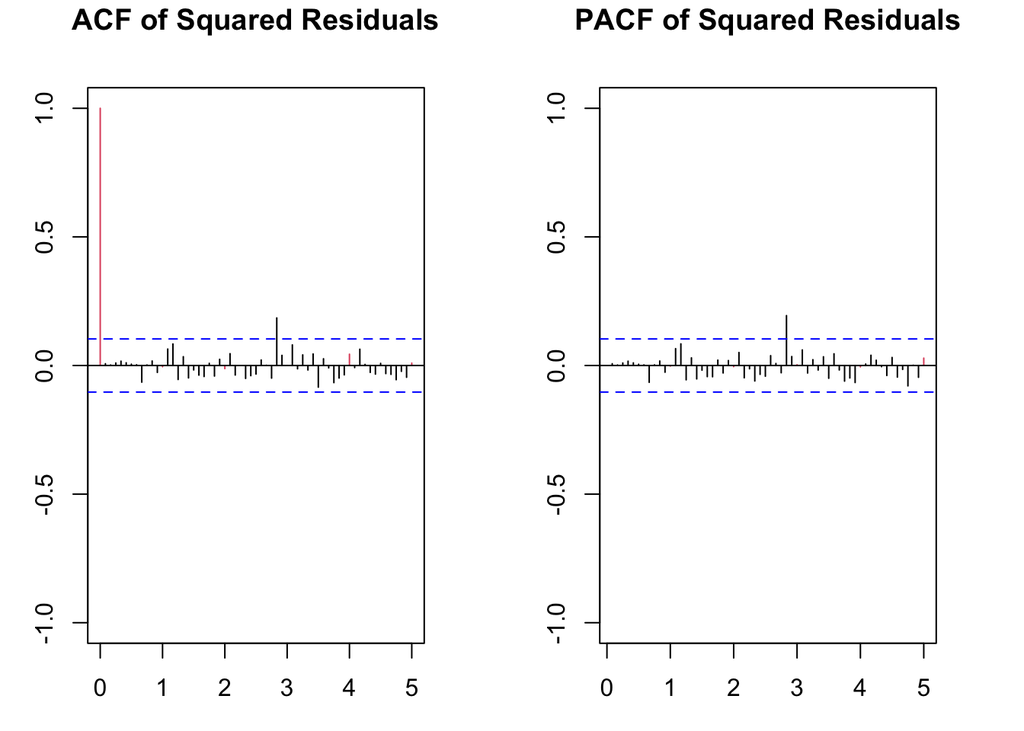

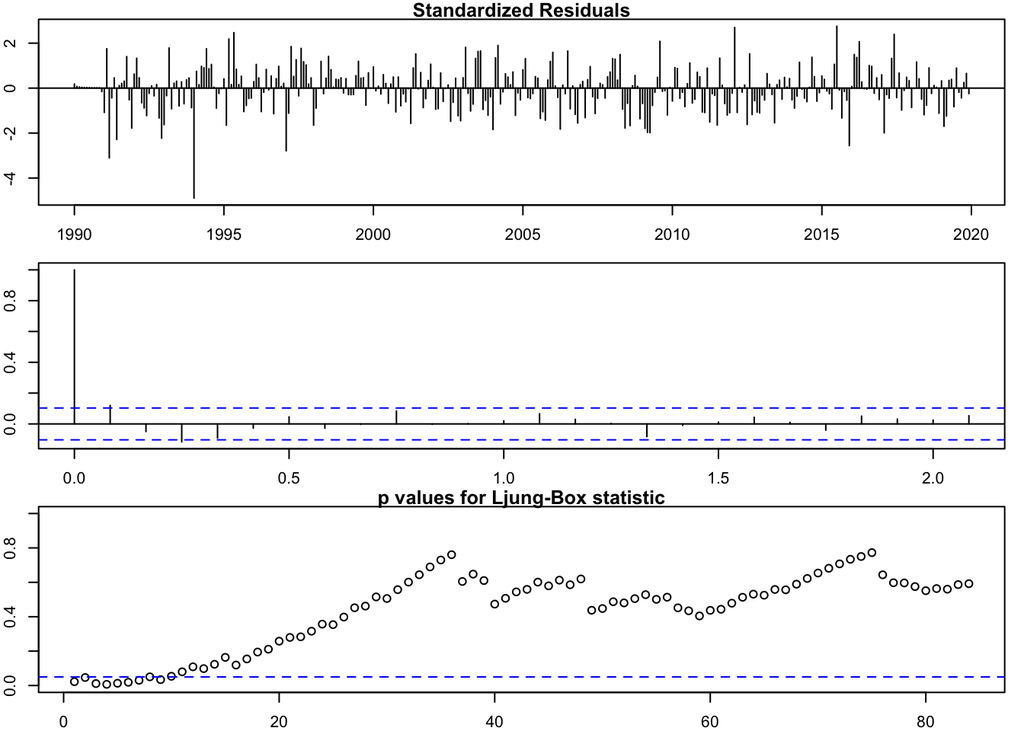

```
##
## --------------------------------------------------------------------
##
## Call:
## arima(x = lnserie, order = c(0, 1, 1), seasonal = list(order = c(2, 1, 1), period = 12))
##
## Coefficients:
##           ma1     sar1     sar2     sma1
##       -0.7043  -0.1512  -0.0361  -0.6971
## s.e.   0.0469   0.1024   0.0851   0.0891
##
## sigma^2 estimated as 0.0009214:  log likelihood = 714.44,  aic = -1418.88
##
## Modul of AR Characteristic polynomial Roots:  1.148387 1.148387 1.148387 1.148387 1.148387 1.148387 1.148387 1.148387 1.148387 1.148387 1.148387 1.148387 1.148387 1.148387 1.148387 1.148387 1.148387 1.148387 1.148387 1.148387 1.148387 1.148387 1.148387 1.148387
##
## Modul of MA Characteristic polynomial Roots:  1.030521 1.030521 1.030521 1.030521 1.030521 1.030521 1.030521 1.030521 1.030521 1.030521 1.030521 1.030521 1.419804
##
## Psi-weights (MA(inf))
##
## --------------------
##      psi 1      psi 2      psi 3      psi 4      psi 5      psi 6      psi 7
## -0.7043225  0.0000000  0.0000000  0.0000000  0.0000000  0.0000000  0.0000000
##      psi 8      psi 9     psi 10     psi 11     psi 12     psi 13     psi 14
##  0.0000000  0.0000000  0.0000000  0.0000000 -0.8483062  0.5974812  0.0000000
##     psi 15     psi 16     psi 17     psi 18     psi 19     psi 20
##  0.0000000  0.0000000  0.0000000  0.0000000  0.0000000  0.0000000
```

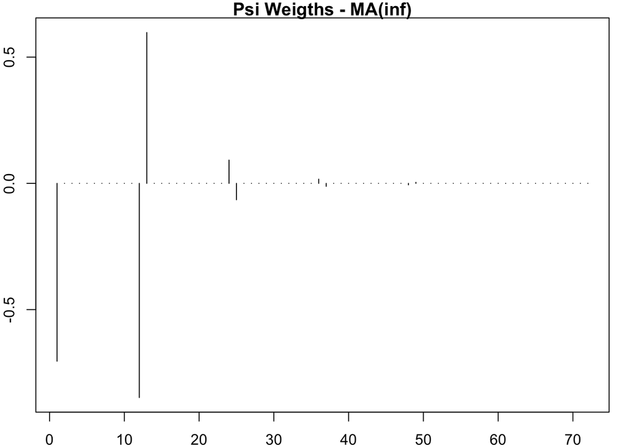

```
##
## Pi-weights (AR(inf))
##
## --------------------
##        pi 1        pi 2        pi 3        pi 4        pi 5        pi 6
## -0.70432254 -0.49607023 -0.34939344 -0.24608568 -0.17332369 -0.12207578
##        pi 7        pi 8        pi 9       pi 10       pi 11       pi 12
## -0.08598072 -0.06055816 -0.04265248 -0.03004110 -0.02115862 -0.86320874
##       pi 13       pi 14       pi 15       pi 16       pi 17       pi 18
## -0.60797737 -0.42821216 -0.30159948 -0.21242331 -0.14961452 -0.10537688
##       pi 19       pi 20
## -0.07421931 -0.05227433
```

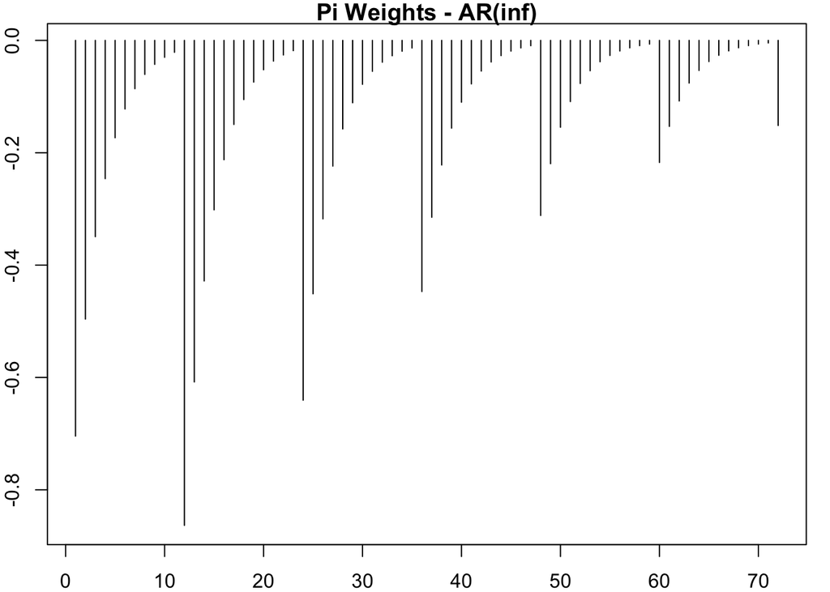

```
##
## Normality Tests
##
## --------------------
##
##  Shapiro-Wilk normality test
##
## data:  resid(model)
## W = 0.98591, p-value = 0.001408
##
##
##  Anderson-Darling normality test
##
## data:  resid(model)
## A = 0.74778, p-value = 0.0511
##
##
##  Jarque Bera Test
##
## data:  resid(model)
## X-squared = 38.569, df = 2, p-value = 4.216e-09
##
##
## Homoscedasticity Test
##
## --------------------
##
##  studentized Breusch-Pagan test
##
## data:  resid(model) ~ I(obs - resid(model))
## BP = 0.46203, df = 1, p-value = 0.4967
##
##
## Independence Tests
##
## --------------------
##
##  Durbin-Watson test
##
## data:  resid(model) ~ I(1:length(resid(model)))
## DW = 1.76, p-value = 0.009727
## alternative hypothesis: true autocorrelation is greater than 0
##
##
## Ljung-Box test
##      lag.df statistic     p.value
## [1,]      1  5.228390 0.022221089
## [2,]      2  6.134943 0.046538675
## [3,]      3 11.083647 0.011282057
## [4,]      4 14.137037 0.006870293
## [5,]     12 18.233267 0.108789119
## [6,]     24 25.928596 0.356798003
## [7,]     36 29.720921 0.760570542
## [8,]     48 44.442294 0.619417198
```

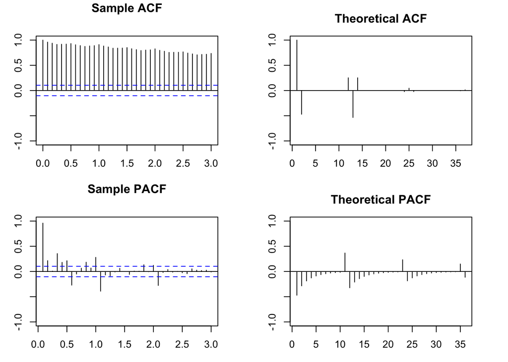

```r
validation(mod2,lnserie)
```

```r
check_stationarity_invertibility(mod2, "SARIMA(0,1,1)(2,1,1)")
```

```
##
## ==========  SARIMA(0,1,1)(2,1,1)  ==========
##
## Modulus of AR Roots (Stationarity):
##  1.148387 1.148387 1.148387 1.148387 1.148387 1.148387 1.148387 1.148387 1.148387 1.148387 1.148387 1.148387 1.148387 1.148387 1.148387 1.148387 1.148387 1.148387 1.148387 1.148387 1.148387 1.148387 1.148387 1.148387
## => AR part is STATIONARY (causal)
##
## Modulus of MA Roots (Invertibility):
##  1.030521 1.030521 1.030521 1.030521 1.030521 1.030521 1.030521 1.030521 1.030521 1.030521 1.030521 1.030521 1.419804
## => MA part is INVERTIBLE
##
## Psi-weights (MA(inf)):
##      psi 1      psi 2      psi 3      psi 4      psi 5      psi 6      psi 7
## -0.7043225  0.0000000  0.0000000  0.0000000  0.0000000  0.0000000  0.0000000
##      psi 8      psi 9     psi 10     psi 11     psi 12     psi 13     psi 14
##  0.0000000  0.0000000  0.0000000  0.0000000 -0.8483062  0.5974812  0.0000000
##     psi 15     psi 16     psi 17     psi 18     psi 19     psi 20
##  0.0000000  0.0000000  0.0000000  0.0000000  0.0000000  0.0000000
```

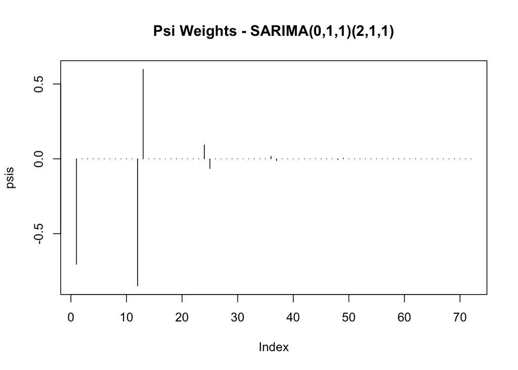

```
##
## Pi-weights (AR(inf)):
##        pi 1        pi 2        pi 3        pi 4        pi 5        pi 6
## -0.70432254 -0.49607023 -0.34939344 -0.24608568 -0.17332369 -0.12207578
##        pi 7        pi 8        pi 9       pi 10       pi 11       pi 12
## -0.08598072 -0.06055816 -0.04265248 -0.03004110 -0.02115862 -0.86320874
##       pi 13       pi 14       pi 15       pi 16       pi 17       pi 18
## -0.60797737 -0.42821216 -0.30159948 -0.21242331 -0.14961452 -0.10537688
##       pi 19       pi 20
## -0.07421931 -0.05227433
```

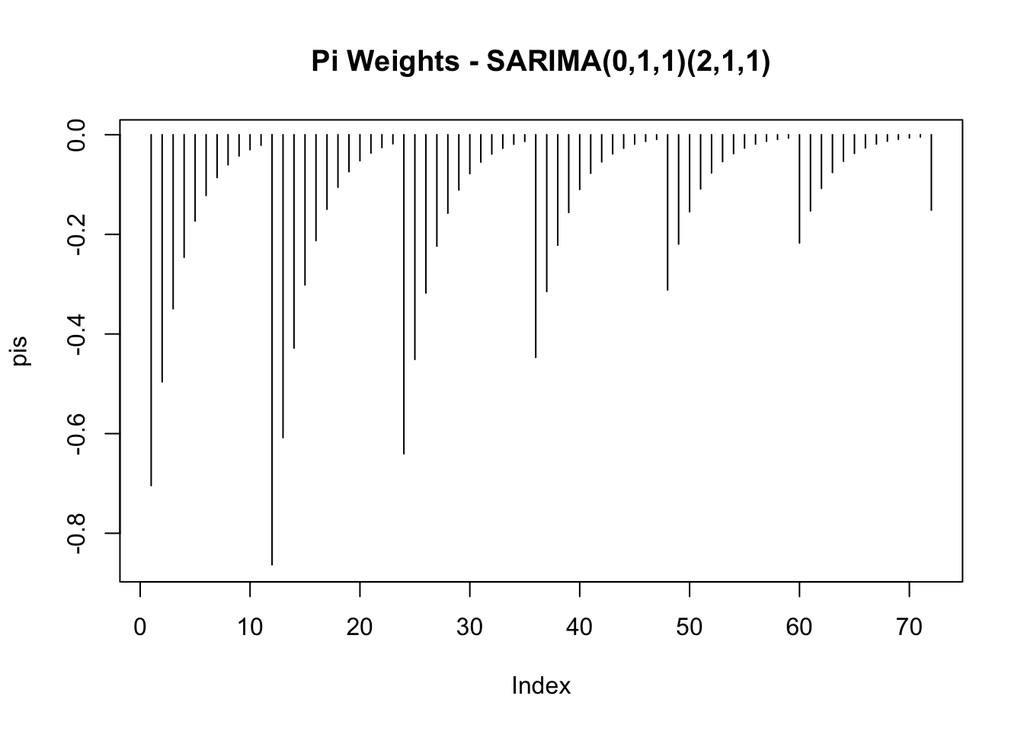